# Data visualization

# 비교 시각화

## 히트맵 만들기

2008년의 NBA 농구선수 통계이다

첫번째열은 선수이름, 나머지는 선수 기록 데이터다

```r
bball = read.csv("http://datasets.flowingdata.com/ppg2008.csv",
                 header = T)

head(bball)
```

```
##             Name  G  MIN  PTS  FGM  FGA   FGP FTM FTA   FTP X3PM X3PA
## 1   Dwyane Wade  79 38.6 30.2 10.8 22.0 0.491 7.5 9.8 0.765  1.1  3.5
## 2  LeBron James  81 37.7 28.4  9.7 19.9 0.489 7.3 9.4 0.780  1.6  4.7
## 3   Kobe Bryant  82 36.2 26.8  9.8 20.9 0.467 5.9 6.9 0.856  1.4  4.1
## 4 Dirk Nowitzki  81 37.7 25.9  9.6 20.0 0.479 6.0 6.7 0.890  0.8  2.1
## 5 Danny Granger  67 36.2 25.8  8.5 19.1 0.447 6.0 6.9 0.878  2.7  6.7
## 6  Kevin Durant  74 39.0 25.3  8.9 18.8 0.476 6.1 7.1 0.863  1.3  3.1
##    X3PP ORB DRB TRB AST STL BLK  TO  PF
## 1 0.317 1.1 3.9 5.0 7.5 2.2 1.3 3.4 2.3
## 2 0.344 1.3 6.3 7.6 7.2 1.7 1.1 3.0 1.7
## 3 0.351 1.1 4.1 5.2 4.9 1.5 0.5 2.6 2.3
## 4 0.359 1.1 7.3 8.4 2.4 0.8 0.8 1.9 2.2
## 5 0.404 0.7 4.4 5.1 2.7 1.0 1.4 2.5 3.1
## 6 0.422 1.0 5.5 6.5 2.8 1.3 0.7 3.0 1.8
```

`order` 함수를 이용해 원하는 값을 기준으로 정렬한다

행이름을 숫자에서 선수이름으로 바꾸자

```r
bball_byfgp = bball[order(bball$FGP, decreasing =T),]

bball = bball[order(bball$PTS, decreasing = F),]

row.names(bball) = bball$Name #행이름을 선수 이름으로

bball = bball[,2:20]
```

히트맵을 그리려면 데이터프레임이 아니라 행렬 형태여야 한다

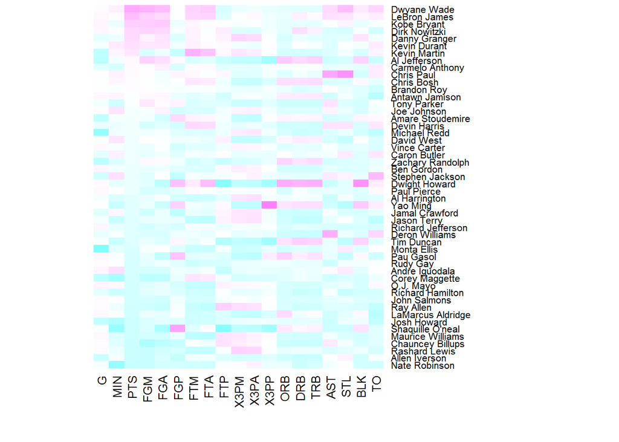

```r
bball_matrix = data.matrix(bball)

bball_heatmap = heatmap(bball_matrix,
                        Rowv = NA,
                        Colv = NA,
                        col = cm.colors(256),
                        scale = "column",
                        margins = c(5,10))
```

scale 인수를 column으로 설정하면 최대최소값을 전체 행렬이 아니라 열기준으로 결정

`cm.colors()` 사용할 색상의 범위를 파랑(cyan)부터 빨강(magenta)으로 설정

입력한 숫자 단계(여기서는 256) 길이의 파랑에서 빨강까지의 색상범위를 16진수 색상코드 벡터로 반환

`?cm.colors` 를 입력하여 자세한 도움말 확인 가능

따뜻한 색감으로 바꿔보자

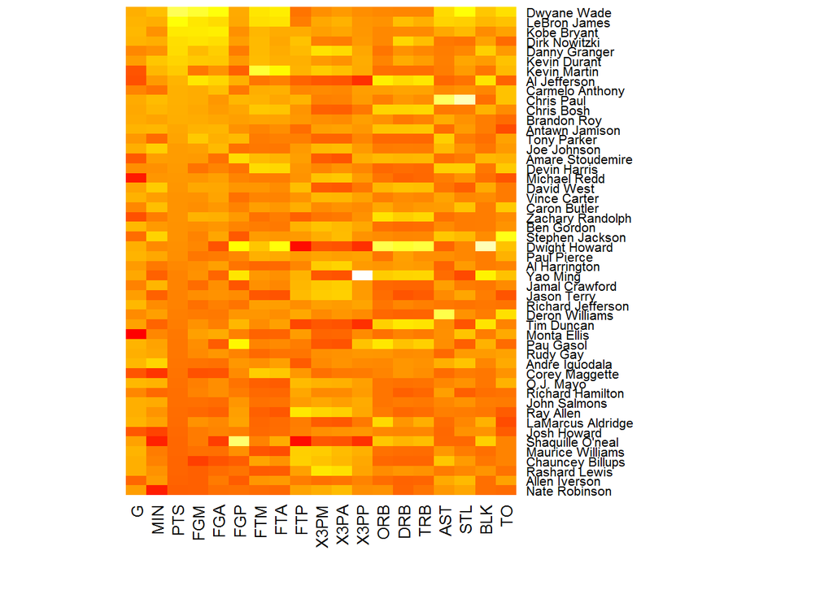

```r
bball_heatmap = heatmap(bball_matrix,
                        Rowv = NA,
                        Colv = NA,
                        col = heat.colors(256),
                        scale = "column",
                        margins = c(5,10))
```

```r
cm.colors(10) #10개의 색상 벡터를 확인할 수 있다.
```

```
##  [1] "#80FFFFFF" "#99FFFFFF" "#B3FFFFFF" "#CCFFFFFF" "#E6FFFFFF"
##  [6] "#FFE6FFFF" "#FFCCFFFF" "#FFB3FFFF" "#FF99FFFF" "#FF80FFFF"
```

0to255 에서 찾아보는 것도 좋다

색상 코드를 직접 입력해보자

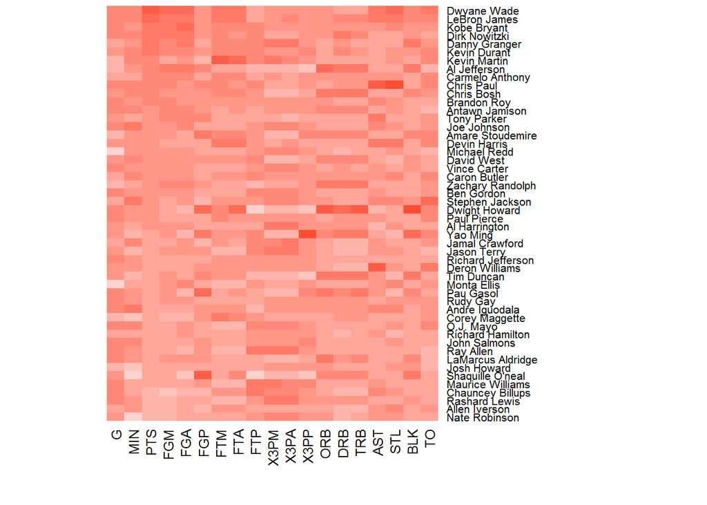

```r
red_colors = c("#ffd3cd","#ffc4bc", "#ffb5ab", "#ffa69a", "#ff9789", "#ff8978", "#ff7a67", "#ff6b56", "#ff5c45", "#ff4d34")

bball_heatmap = heatmap(bball_matrix,
                        Rowv = NA,
                        Colv = NA,
                        col = red_colors,
                        scale = "column",
                        margins = c(5,10))
```

## RColorBrewer 패키지

색상 고르기 귀찮을때 설치한다

`?brewer.pal` 을 통해 자세한 옵션 확인

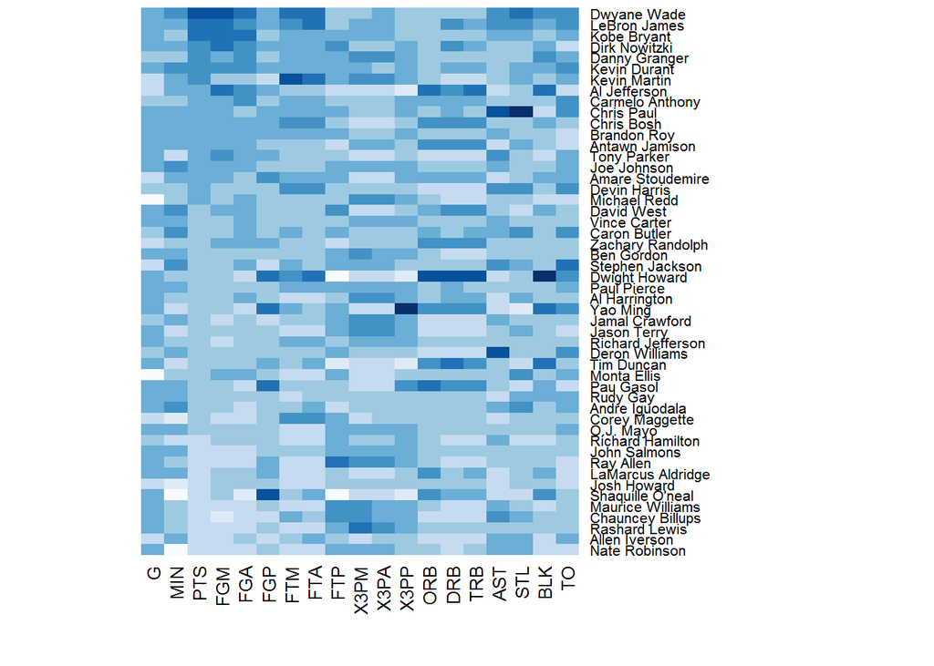

```r
#install.packages("RColorBrewer")
library(RColorBrewer)
bball_heatmap = heatmap(bball_matrix, Rowv = NA, Colv = NA, col=brewer.pal(9,"Blues"), scale = "column", margins = c(5,10))
```

# Star Chart

몇 개의 축을 그리고 중앙으로부터의 거리를 통해 수치를 나타낸다

남자들의 경우 위닝에서 선수들 능력치를 본다고 생각하면 된다

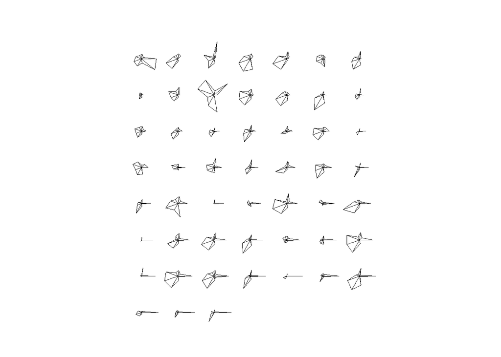

```r
crime = read.csv("http://datasets.flowingdata.com/crimeRatesByState2005.csv",
                 sep = ",",
                 header = T) #얘도 다시
stars(crime)
```

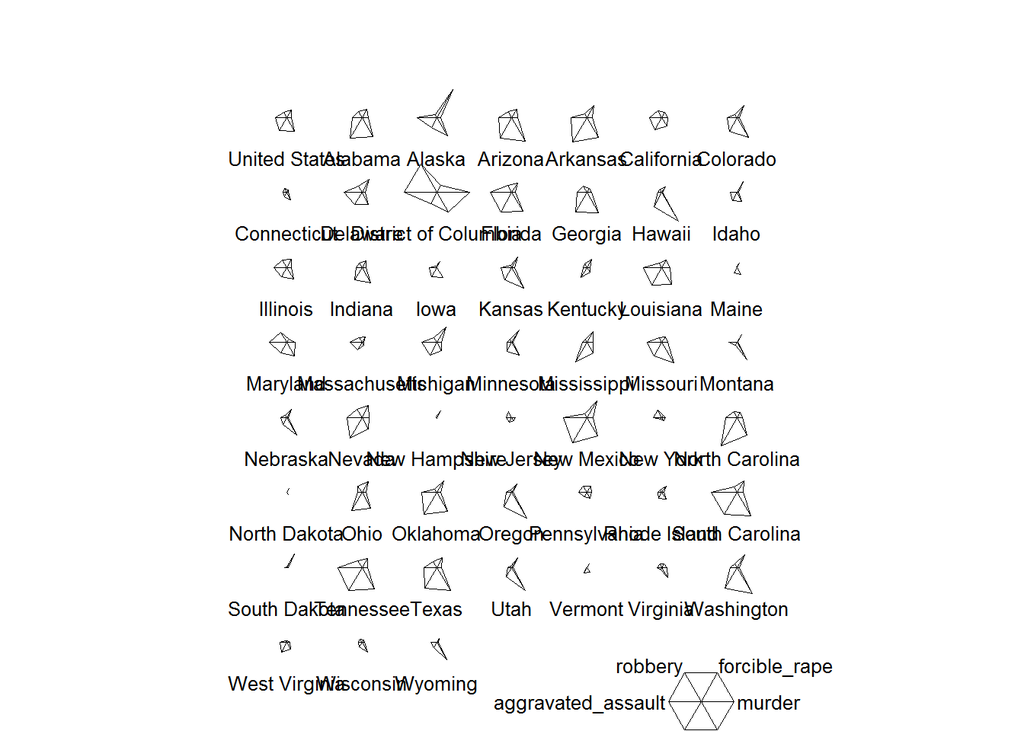

```r
row.names(crime) = crime$state #주 이름을 행이름으로
crime = crime[,2:7] #테이블에서 주 이름을 제거
stars(crime,
      flip.labels = FALSE,
      key.loc = c(15,0.5))
```

flip.labels를 기본값인 T로 놔두면 라벨을 차트의 높이에 따라 위아래를 오가며 배치한다.

key.loc은 범례 위치인것같다

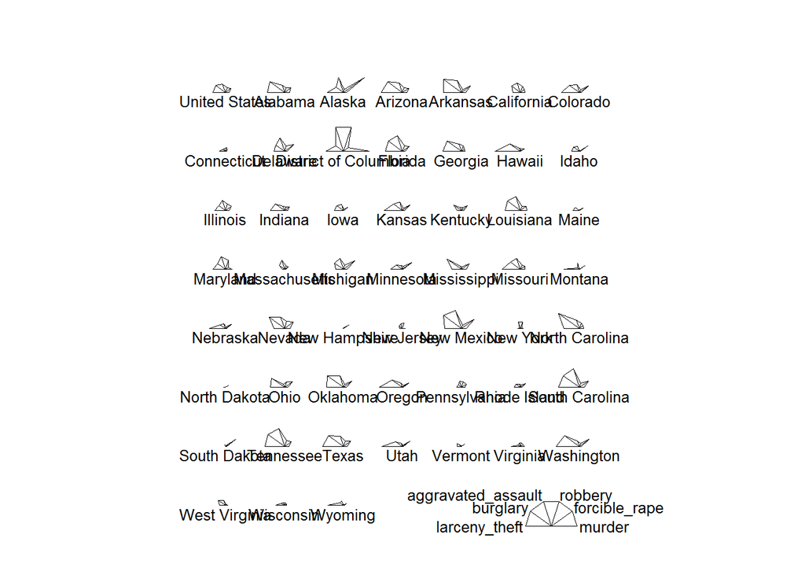

```r
stars(crime,
      flip.labels = FALSE,
      key.loc = c(15,1.5),
      full = FALSE)
```

full옵션을 끄면 윗부분만 가지고 그린다

## Nightingale chart / Polar Area Diagram

`draw.segments` 옵션을 켜면 점의 위치 대신 거리로 수치를 나타낸다

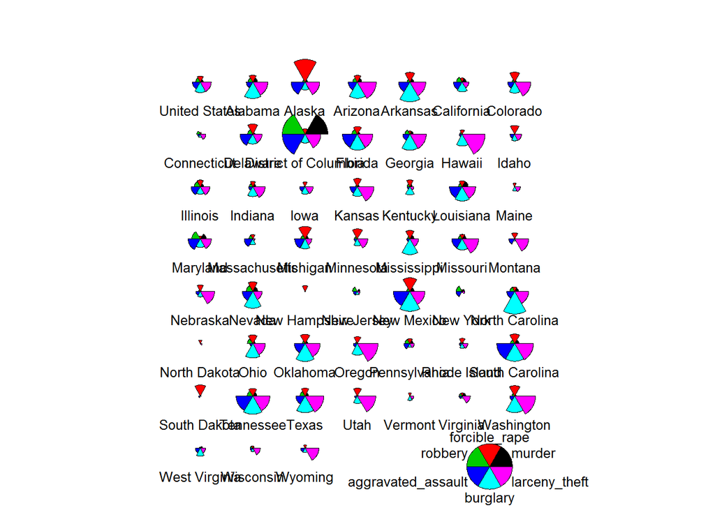

```r
stars(crime,
      flip.labels = FALSE,
      key.loc = c(15,1.5),
      draw.segments = TRUE)
```

## 평행좌표계 Parallel coordinates

```r
education = read.csv("http://datasets.flowingdata.com/education.csv",
                     header=T)

head(education)
```

```
##           state reading math writing percent_graduates_sat
## 1 United States     501  515     493                    46
## 2       Alabama     557  552     549                     7
## 3        Alaska     520  516     492                    46
## 4       Arizona     516  521     497                    26
## 5      Arkansas     572  572     556                     5
## 6    California     500  513     498                    49
##   pupil_staff_ratio dropout_rate
## 1               7.9          4.4
## 2               6.7          2.3
## 3               7.9          7.3
## 4              10.4          7.6
## 5               6.8          4.6
## 6              10.9          5.5
```

변수들을 분명한 상관관계로 엮을 수 있을지 알아보자

ex) 고교 중퇴율이 높은 주는 과연 평균 SAT점수도 낮을까?

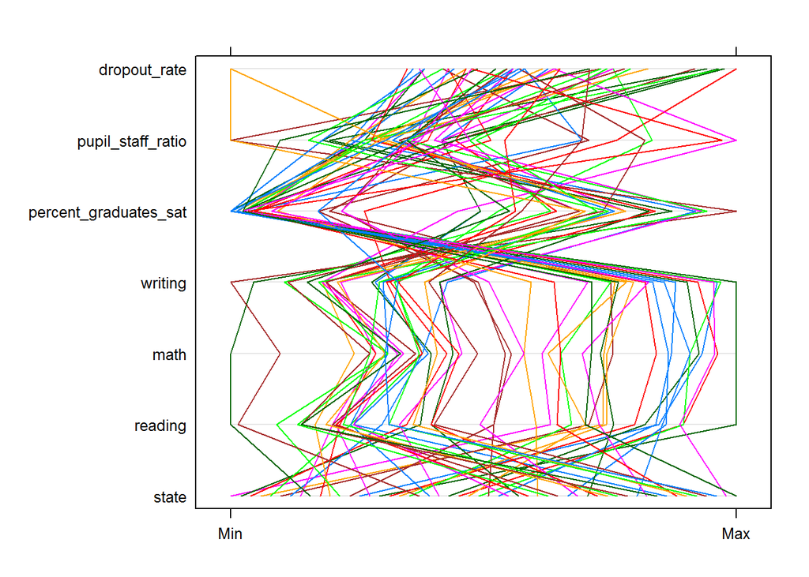

```r
library(lattice)

parallelplot(education)
```

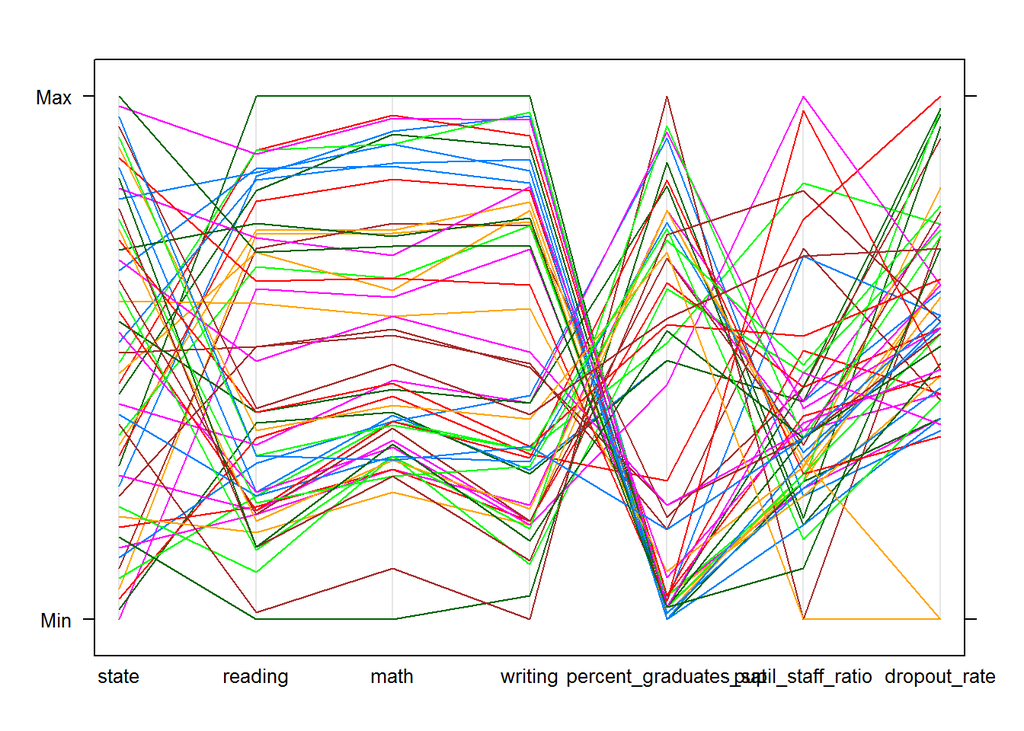

```r
parallelplot(education,
             horizontal.axis = FALSE)  #취향따라...
```

state열은 빼고, 검은색으로 바꿔보자

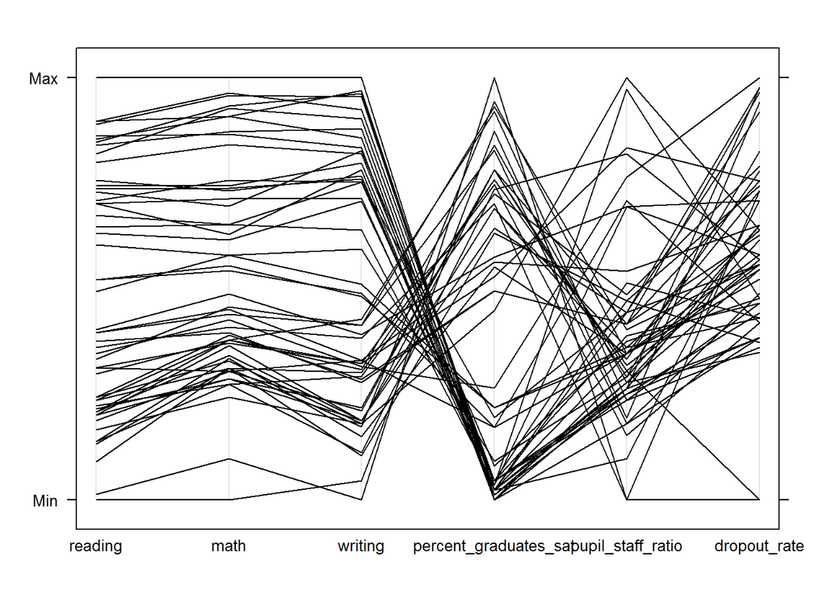

```r
parallelplot(education[,2:7],
             horizontal.axis = FALSE,
             col = "#000000")
```

읽기,수학,쓰기는 평행에 가깝다

SAT점수와 응시율? 높은 평균점수는 낮은 응시율을 보이고 그 반대도 보인다

읽기 점수를 기준으로 50%씩 나누어서 상위는 검정색, 하위는 회색으로 하자

중앙값은 `summary()`를 통해 확인

```r
summary(education) #reading의 중앙값은 523이다
```

```
##         state       reading           math          writing
##  Alabama   : 1   Min.   :466.0   Min.   :451.0   Min.   :455.0
##  Alaska    : 1   1st Qu.:497.8   1st Qu.:505.8   1st Qu.:490.0
##  Arizona   : 1   Median :523.0   Median :525.5   Median :510.0
##  Arkansas  : 1   Mean   :533.8   Mean   :538.4   Mean   :520.8
##  California: 1   3rd Qu.:571.2   3rd Qu.:571.2   3rd Qu.:557.5
##  Colorado  : 1   Max.   :610.0   Max.   :615.0   Max.   :588.0
##  (Other)   :46
##  percent_graduates_sat pupil_staff_ratio  dropout_rate
##  Min.   : 3.00         Min.   : 4.900    Min.   :-1.000
##  1st Qu.: 6.75         1st Qu.: 6.800    1st Qu.: 2.950
##  Median :34.00         Median : 7.400    Median : 3.950
##  Mean   :37.35         Mean   : 7.729    Mean   : 4.079
##  3rd Qu.:66.25         3rd Qu.: 8.150    3rd Qu.: 5.300
##  Max.   :90.00         Max.   :12.100    Max.   : 7.600
##
```

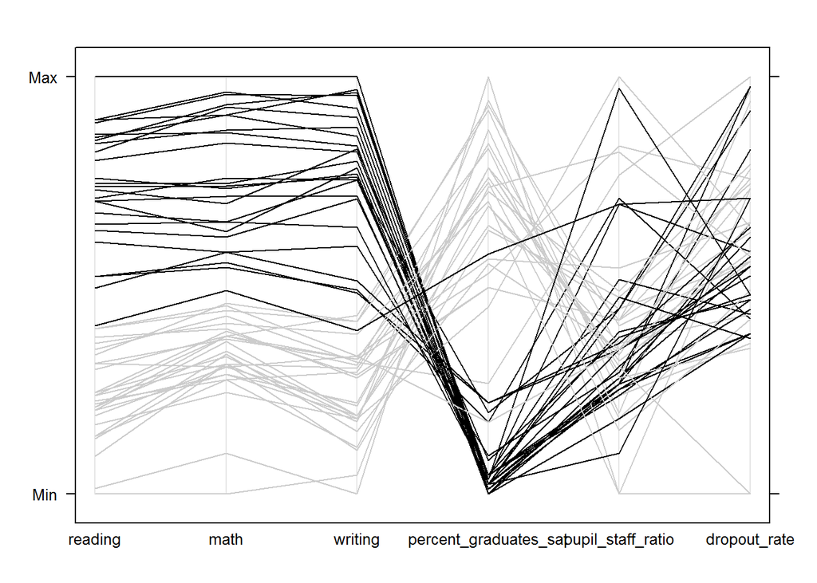

```r
reading_colors = c()
for (i in 1:length(education$state)){
  if (education$reading[i] > 523){
      col = "#000000"
  } else {
      col = "#cccccc"
  }
  reading_colors = c(reading_colors, col)
}

parallelplot(education[,2:7],
             horizontal.axis = FALSE,
             col = reading_colors)
```

중퇴율의 경우에는 어떨까

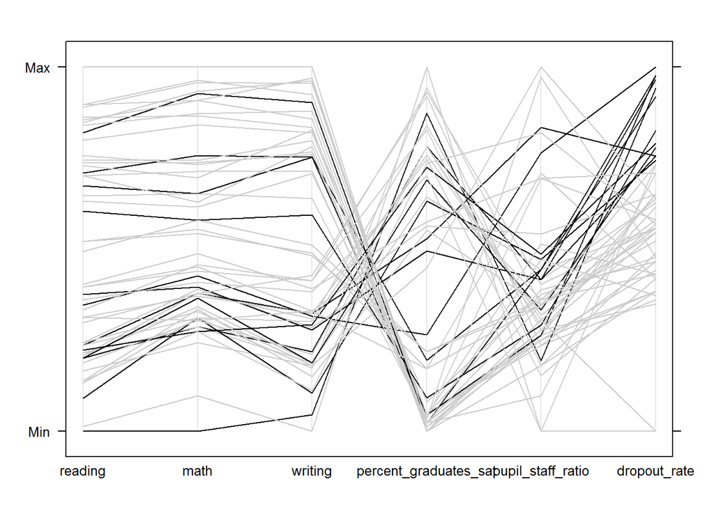

```r
dropout_colors = c()
for (i in 1:length(education$state)){
  if (education$dropout_rate[i] > 5.3){
    col = "#000000"
  } else {
    col = "#cccccc"
  }
  dropout_colors = c(dropout_colors, col)
}
parallelplot(education[,2:7],
             horizontal.axis = FALSE,
             col = dropout_colors)
```

별 의미는 없어보인다

# 다차원척도법(MDS)

모든 변수를 비교해서 나타는 다차원의 관계를 2차원에 투영한 것

```r
education = read.csv("http://datasets.flowingdata.com/education.csv",
                     header = T)
```

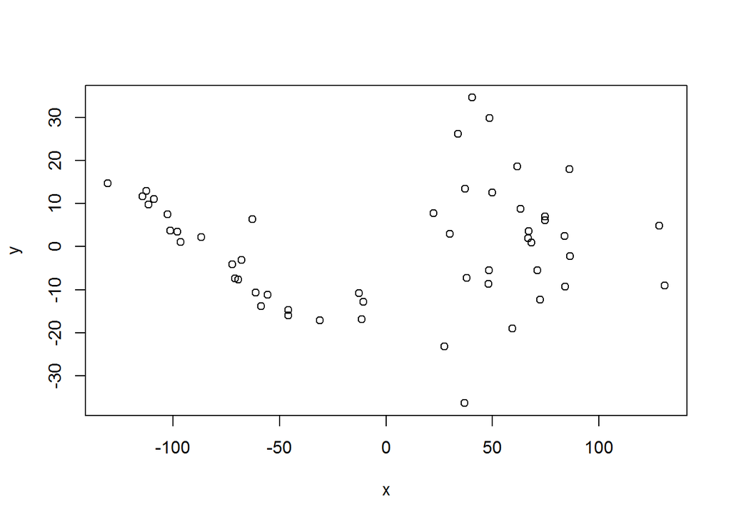

```r
ed.dis = dist(education[,2:7]) #모든 주에 대해서 그 주와 나머지 모든 주 사이의 거리를 구한다, 첫열은 주이름이니 제외
#행렬의 한 위치는 행의 주와 열의 주가 얼마만큼의 (유클리드)거리 로 떨어져 있어야 하는지를 보여준다

ed.dis = cmdscale(ed.dis) #cmdscale함수는 거리 행렬을 입력으로 받아서 각 점을 입력된 거리에 맞게 배치한 좌표를 반환한다

x = ed.dis[,1] #구한 좌표를 변수에 각각 저장
y = ed.dis[,2]

plot(x,y)
```

한 점이 어떤주를 나타내는지 알 수 없으니 라벨을 붙여보자

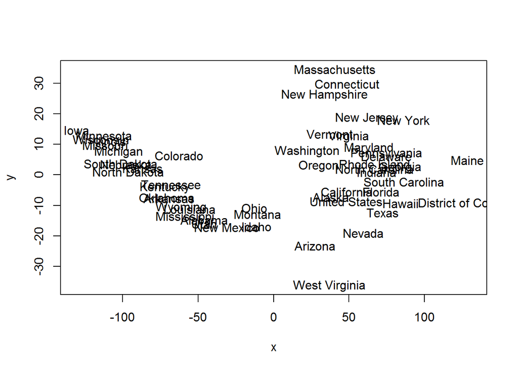

```r
plot(x,y,
     type = "n") # 이러면 아무것도 안나온다

text(x,y,
     labels = education$state)
```

주 라벨에 dropout_colors를 적용해보자

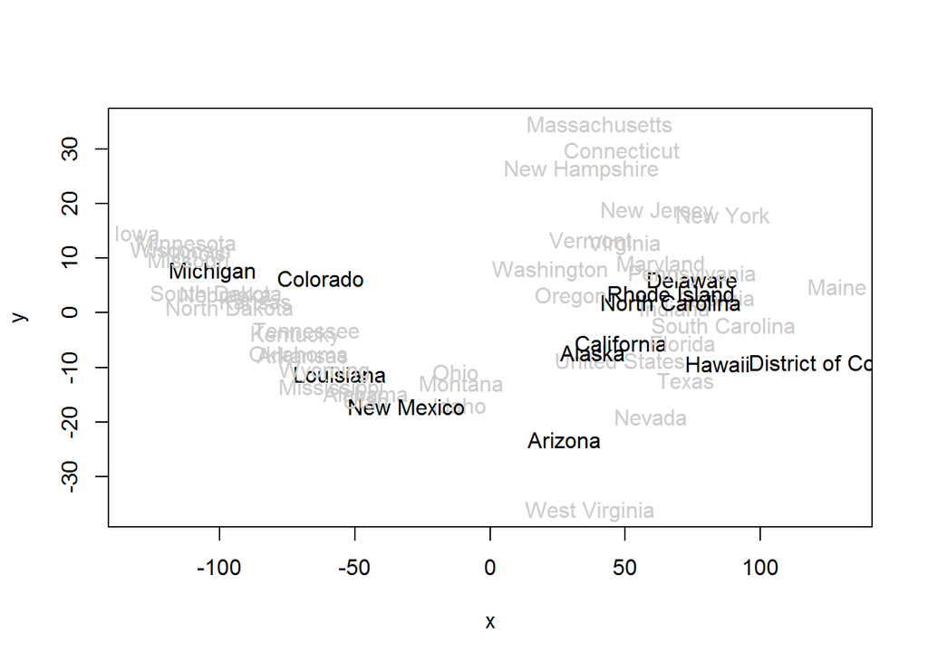

```r
plot(x,y,
     type = "n")
text(x,y,
     labels = education$state,
     col = dropout_colors)
```

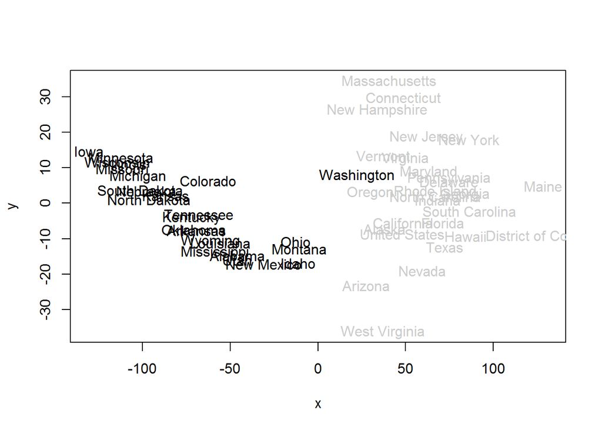

```r
plot(x,y,
     type = "n")
text(x,y,
     labels = education$state,
     col = reading_colors)
```

그룹화 된것이 보인다

Dart Week 7 - End!

그간 수고 많으셨습니다 ^^

#### Data makes the world Artistic. Dart